# Module 7 Project

Callback Cats

2022-11-20

# Introduction

The force produced by the contractions of skeletal muscle allows for movement and stabilization of joints, among other functions. Muscle generation of tension, or force, is based on the speed and length of the muscle. In particular, sliding filament theory posits that sarcomeres produce force by forming cross-bridges, protein complexes formed from the binding of overlapping actin and myosin. This means that greater cross-bridge formation leads to greater force production. It can then be inferred that sarcomere maximal isometric force is determined by the amount of actin-myosin overlap, which changes with muscle fiber length and implies an optimal length for maximal force production (Fig. 1). In this project, the force-length relationship is studied using human forearm flexors, with muscle length manipulated by altering elbow angle. We can then investigate the effect of muscle fiber length on force generation, as well as how the FL relationship is impacted by fatigue.

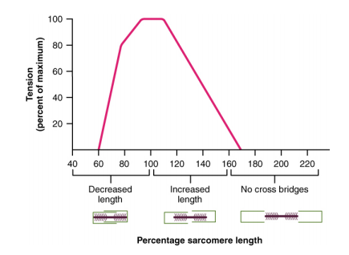

**Fig. 1.** The sarcomere force-length relationship. Graph from Libretexts (2020).

A previous study (Sharma et al. (2021)), observed the FL relationship by measuring maximum isometric contraction in the forearm over a range of elbow angles, finding that maximal force production occurred at an intermediate elbow angle of 90°. Muanjai et al. (2020) examined knee extensor isometric maximal voluntary contractions (MVCs) at various angles before and after eccentric exercise, finding a loss of force after exercise. Though the authors attribute the force decrease to a deficit in excitation-contraction coupling, it is clear that fatigue has an effect on force production.

We seek to construct isometric force-angle curves for forearm flexor MVCs at a number of elbow angles. The angle (θmax) at which non-fatigued (control) maximum isometric force occurs will be compared to the θmax of fatigued MVCs. The data collected here will help us to answer if isometric MVCs from different subjects coalesce around a typical FL relationship, and if θmax differs significantly between control and fatigue FL relationships.

# Methods

To begin, each group member performed forearm contractions at twelve different elbow angles and these were measured as the control using DAQ. Then, each individual fatigued their elbow flexor muscles and produced maximum voluntary contractions at the same angles as the control. After compiling the MVC data that was collected, the maximum force at each angle and the maximum force across all angles for each group member was found. Next, to normalize the data on a scale of 0 to 1 (1 being the highest recorded force), the maximum values of each angle was divided by Fmax. After normalizing the data, the maximum values were plotted, along with a graph of the mean normalized forces for each angle and experiment. To find the best fit, three models were created. The model found to fit best (lowest AICc score) was used to predict the force for 1000 angles. With the collected data, AIC tests were performed and then the AICs and fits tables were joined. Next, ANOVA tests were performed to test for significant difference of θmax between the control and fatigue FL relationships. Lastly, the mean of θmax and standard error of the mean was calculated.

Experimental Protocol: 1. Construct and program a load-cell data acquisition system. 2. Make a goniometer. 3. Record isometric MVCs at 12 distinct elbow angles to act as a control. 4. Eccentrically fatigued our flexors and waited 2 minutes. 5. Repeat recording isometric MVCs at the same 12 distinct elbow angles. 6. Upload data to directory. 7. Analyze data to find maximum force (Fmax) for each recording, and to find maximum force across all angles for each experiment (control or fatigued) for each individual and then divide all maximum values for that experiment by Fmax to calculate θmax .

#### Setting Up Dataset for Analysis

```r
library(tidyverse)
library(MuMIn)
library(ggplot2)
library(dplyr)
```

Here we are reading in the data and calculating the normalized force data.

```r
k <- list.files("./Project 8 Data", full.names = T,pattern = ".csv")
print(k)
k.l <- list()

for(i in k){
  met.dat <- unlist(strsplit(i,"_"))
  sub <- met.dat[2]
  ang <- as.numeric(met.dat[3])
  exp <- gsub("\\..+","",met.dat[4])
  k.l[[i]] <- read_delim(i,delim = " ", col_names = c("Reading","Force","Unit"), id="Experiment",progress = FALSE) %>%select(Force)%>%
    mutate(sub=sub,ang=ang,exp=exp)
}

data <- do.call(rbind, k.l)
data <- data%>%
  group_by(sub,exp,ang)%>%
  summarise(max.force=max(abs(Force), na.rm=TRUE), n=n())

data <- na.omit(data)

data.joined <- data%>%
  group_by(sub,exp)%>%
  summarize(max.f2 = max(max.force))%>%
  left_join(data)%>%
  mutate(norm.force=max.force/max.f2)

data.con <- filter(data.joined,exp=="control")
data.fat <- filter(data.joined,exp=="fatigue")
```

[output not shown]

Here we are just separating the normalized force and angle values for the control and fatigue data respectively.

```r
ang.con <- data.con$ang
normF.con <- data.con$norm.force

ang.fat <- data.fat$ang
normF.fat <- data.fat$norm.force
```